# Midterm

## 2.2 make an animation plot

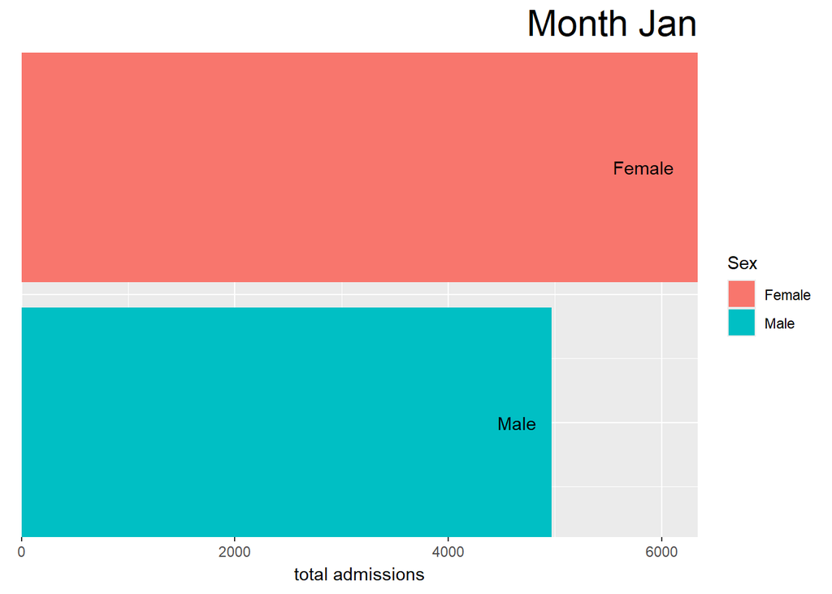

```r
d1 <- df %>%
  group_by(moa_name, sex_name) %>%
  summarize(frequency = n(), .groups = "drop")
d2 <- d1 %>%
  group_by(moa_name) %>%
  mutate(rank = rank(-frequency))

a1 <- d2 %>%
  ggplot(aes(x = rank, y = frequency, group = sex_name, fill = sex_name, label = sex_name)) +
  geom_col() +
  geom_text(aes(
    y = frequency,
    label = sex_name),
    hjust = 1.4) +
  coord_flip(clip = "off", expand = FALSE) +
  scale_x_reverse() +
  labs(title = 'Month {closest_state}',
       x = '',
       y = 'total admissions',
       fill = 'Sex') +
  theme(plot.title = element_text(hjust = 1, size = 22),
        axis.ticks.y = element_blank(),
        axis.text.y = element_blank()) +
  transition_states(moa_name) +
  ease_aes("cubic-in-out")

animate(a1, nframes = 400)
```

```r
anim_save("animatedgif.gif", a1)
```

## 2.3 write a paragraph to summarize the section and give your comments on the results

Like section 1, section 2 showed that there are key trends that emerge when the data is filtered and presented in different ways. visualization across providers, months, age, and gender highlighted these key trends. This can be useful for hospitals and doctors as they can come to anticipate these trends within subsets of their patient populations.

# 3. predictive models

## 3.0 create the target variable

- taking value of low if total charge of a patient (tot) is smaller than the median of total charge, high otherwise

```r
median_tot = median(df$tot)

df$target <- case_when(
  df$tot <= median_tot ~ 'low',
  df$tot > median_tot ~ 'high'
)
```

## 3.1 split data

```r
# filter out rows were raceethn == '' or admtype == ''

df <- df %>% filter(
  raceethn != "")

df <- df %>% filter(
  admtype != ""
)

df_inputs <- df %>% select("age", "sex", "raceethn", "provider", "moa", "mod", "admtype", "campus", "los", "target")

# categorical = factor, numeric = numeric

df_inputs <- df_inputs %>%
  mutate(target = as.factor(target),
         age = as.numeric(age),
         sex = as.factor(sex),
         raceethn = as.factor(raceethn),
         moa = as.factor(moa),
         mod = as.factor(mod),
         admtype = as.factor(admtype),
         campus = as.factor(campus),
         los = as.numeric(los))

# set training split
set.seed(2020)

invisible(splitIndex <- createDataPartition(df_inputs$target, p =0.1,
                                 list = FALSE))

df_train <- df_inputs[splitIndex, ]
df_test <- df_inputs[-splitIndex, ]
```

## 3.2

- train a decision tree using rpart

```r
dt <- rpart(target ~., data = df_train)
```

- plot the decision tree

[figure not shown]

```r
fancyRpartPlot(dt)
```

- plot variable importance ranked by the tree

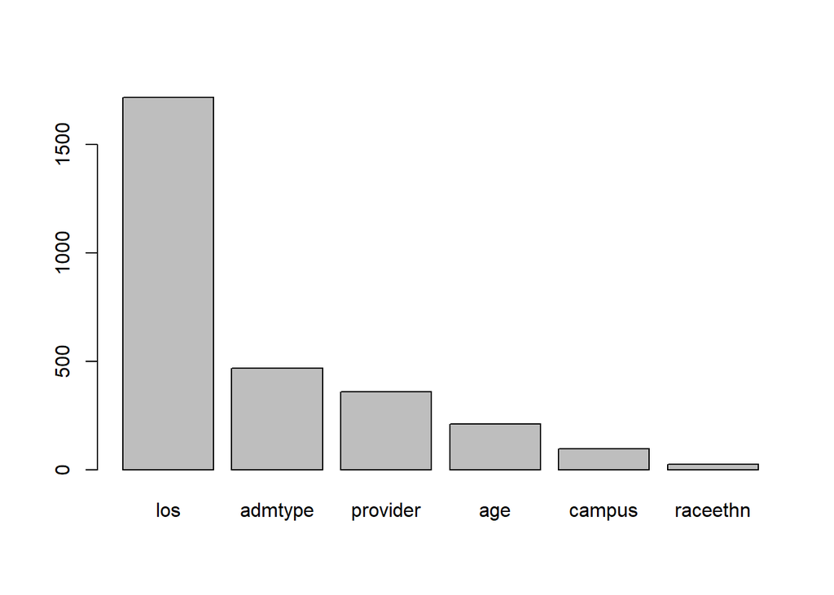

```r
barplot(dt$variable.importance)
```

## 3.3 cross validation 5 folds

```r
# k control is cross validation of 5 folds
trControl = trainControl(method = "cv",
                         number = 5)
```

```r
# rpart with train control
dt2 <- train(target ~., data = df_train,
             method = "rpart",
             trControl = trControl)
```

- training & tune at least 2 different models (two different values for method= in the train function of caret)

```r
# k nearest neighbors
knn <- train(target ~., data = df_train,
              method = "knn",
              trControl = trControl)
```

```r
ranger <- train(target ~., data = df_train,
            method = "ranger",
            trControl = trControl)
```

- plot the hyper parameter tuning plots for each model

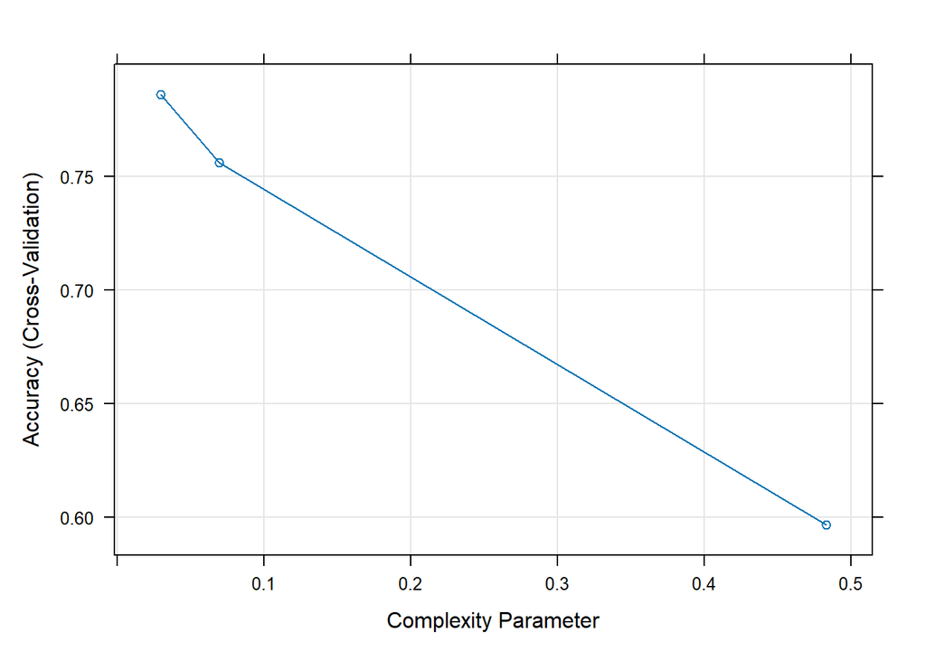

```r
plot(dt2)
```

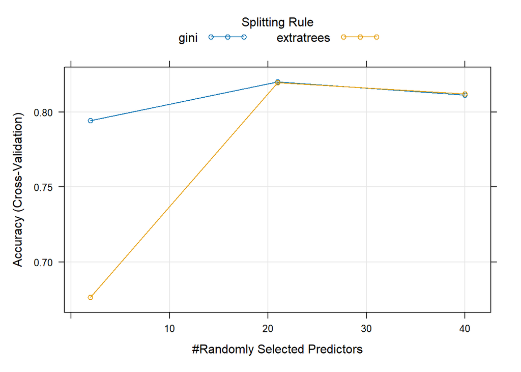

```r
plot(ranger)
```

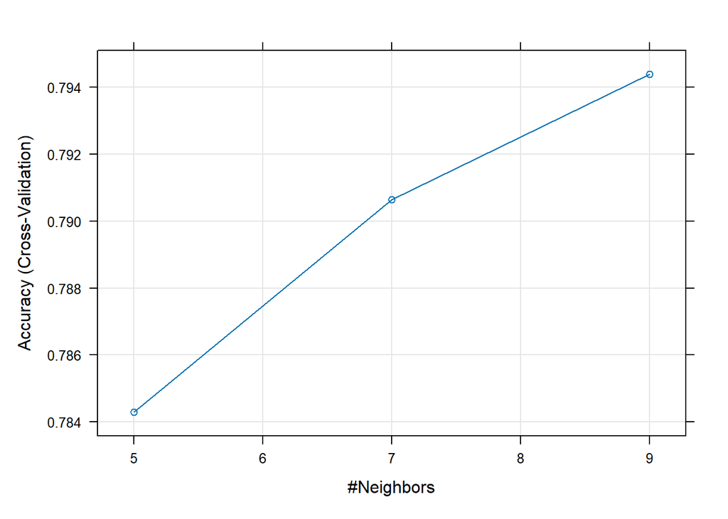

```r
plot(knn)
```

## 3.4

- plot the comparison of the models in 3

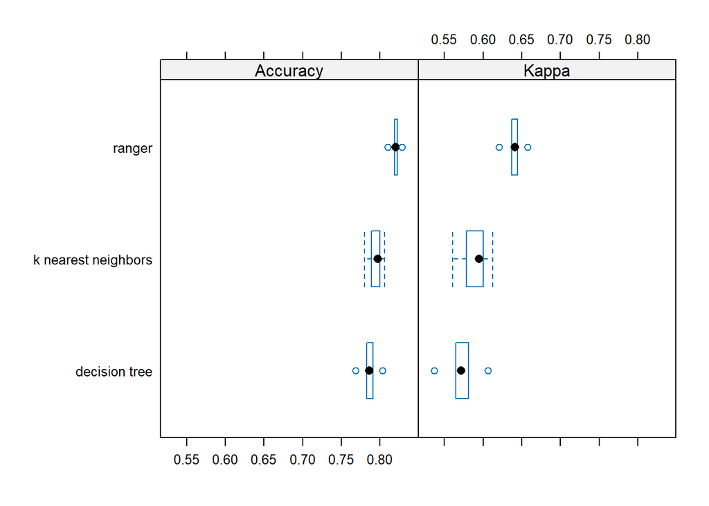

```r
results <- resamples(list ('decision tree' = dt2,
                           'k nearest neighbors' = knn,
                           'ranger' = ranger
                ))

bwplot(results)
```

## 3.5

- what is your final selection for the model? test the accuracy of your final model on the test data

ranger

```r
pred <- predict(ranger, df_test)

cm <- confusionMatrix(data = pred, reference = df_test$target, positive = "high")

cm$overall[1]
```

```
##  Accuracy
## 0.8199791
```

## 3.6

- create another target variable (binary), decide the input variables and redo 1 to 5

new target is if los is greater than median or not

```r
median_los = median(df$los)

df$target2 <- case_when(
  df$los <= median_los ~ 'low',
  df$los > median_los ~ 'high'
)
```

### 3.6.1

- use filter function to filter out rows were reaceethn==’’ or admtype == ’’. Make sure all the categorical variables are factor, numeric variables are numeric. set training: testing split = 10:90

```r
df_inputs2 <- df %>% select("age", "sex", "raceethn", "provider", "moa", "mod", "admtype", "campus", "tot", "target2", "season")

# categorical = factor, numeric = numeric

df_inputs2 <- df_inputs2 %>%
  mutate(target2 = as.factor(target2),
         age = as.numeric(age),
         sex = as.factor(sex),
         prover = as.factor(provider),
         raceethn = as.factor(raceethn),
         moa = as.factor(moa),
         mod = as.factor(mod),
         admtype = as.factor(admtype),
         campus = as.factor(campus),
         season = as.factor(season))
# set training split
set.seed(2020)

invisible(splitIndex2 <- createDataPartition(df_inputs2$target2, p =0.1,
                                 list = FALSE))

df_train2 <- df_inputs2[splitIndex2, ]
df_test2 <- df_inputs2[-splitIndex2, ]
```

### 3.6.2

- train a decision tree using rpart

```r
dt3 <- rpart(target2 ~., data = df_train2)
```

- plot the decision tree

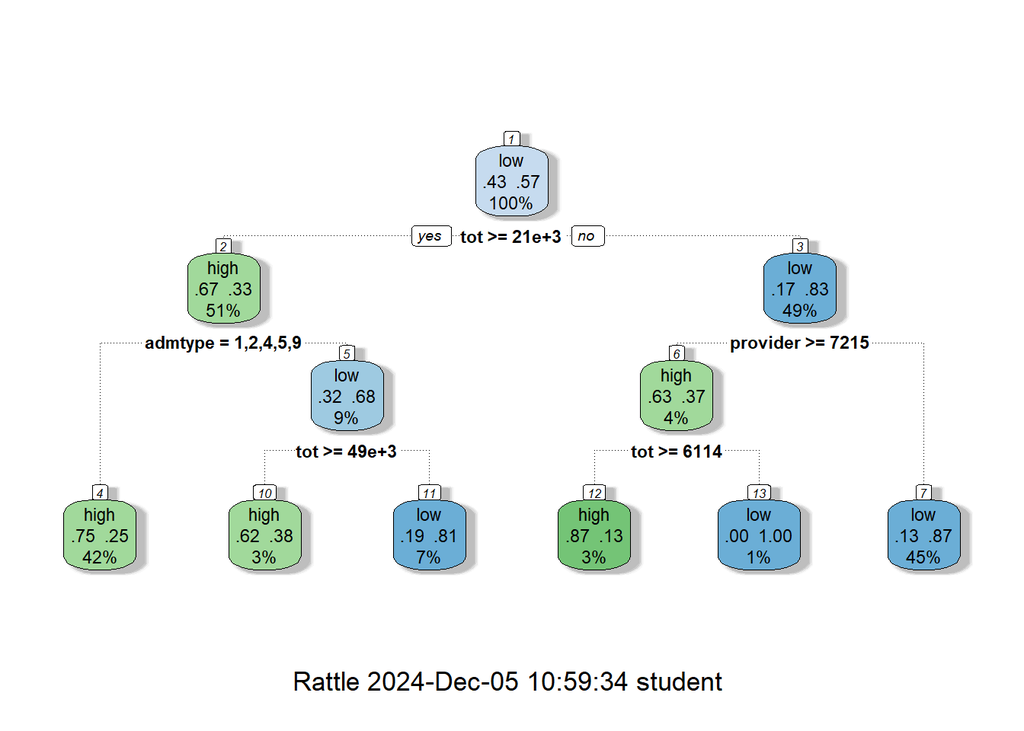

```r
fancyRpartPlot(dt3)
```

- plot variable importance ranked by the tree

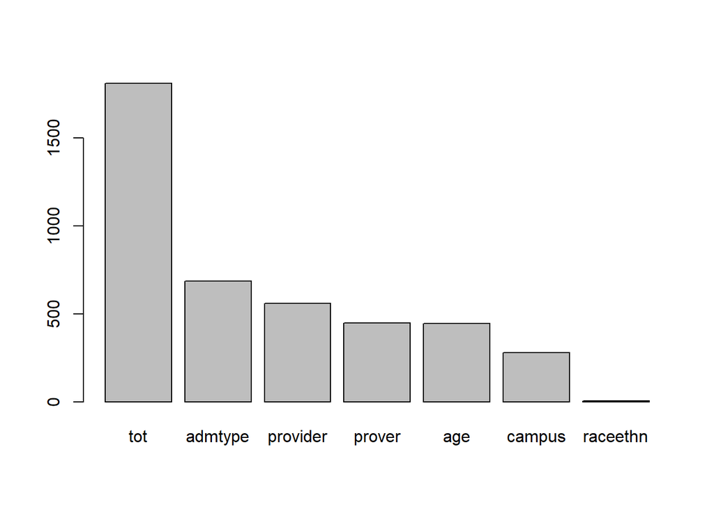

```r
barplot(dt3$variable.importance)
```

### 3.6.3

- using caret for this question, set raining control to be: use cross validation of 5 folds across all models

```r
# k control is cross validation of 5 folds
trControl = trainControl(method = "cv",
                         number = 5)
```

```r
# rpart with train control
dt4 <- train(target2 ~., data = df_train2,
             method = "rpart",
             trControl = trControl)
```

- training & tune at least 2 different models (two different values for method= in the train function of caret)

```r
# random forest
invisible(nnet <- train(target2 ~., data = df_train2,
             method = "nnet",
             trControl = trControl))
# k nearest neighbors
ranger <- train(target2 ~., data = df_train2,
              method = "ranger",
              trControl = trControl)
```

- plot the hyper parameter tuning plots for each model

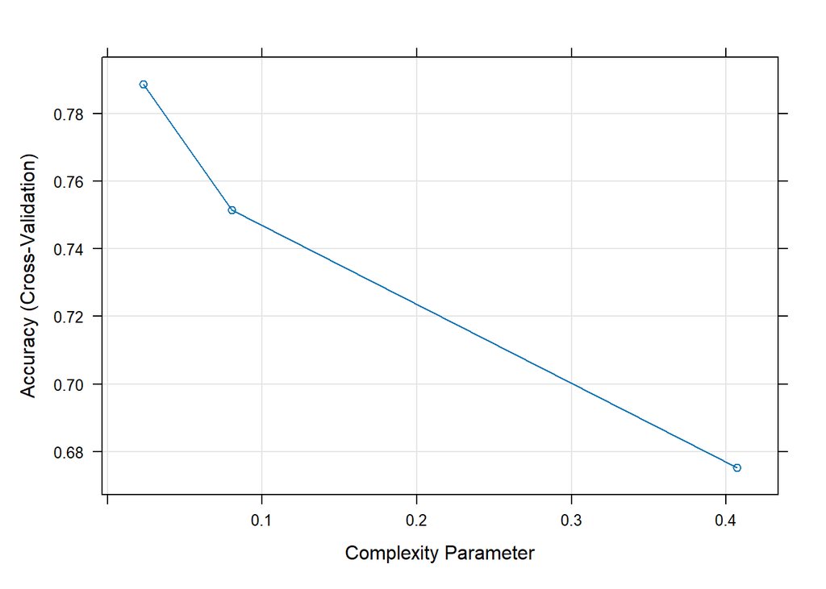

```r
plot(dt4)
```

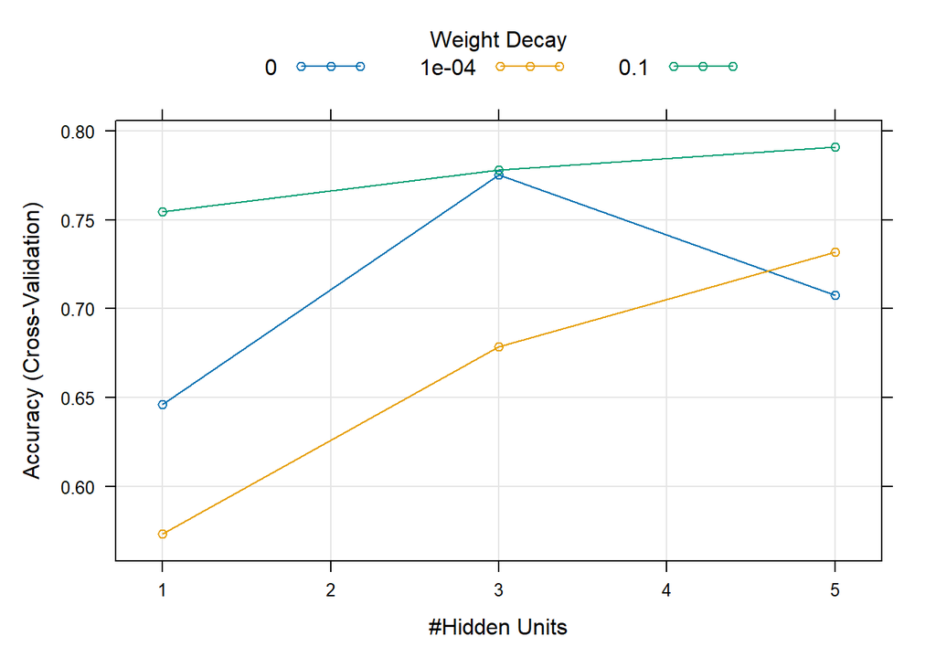

```r
plot(nnet)
```

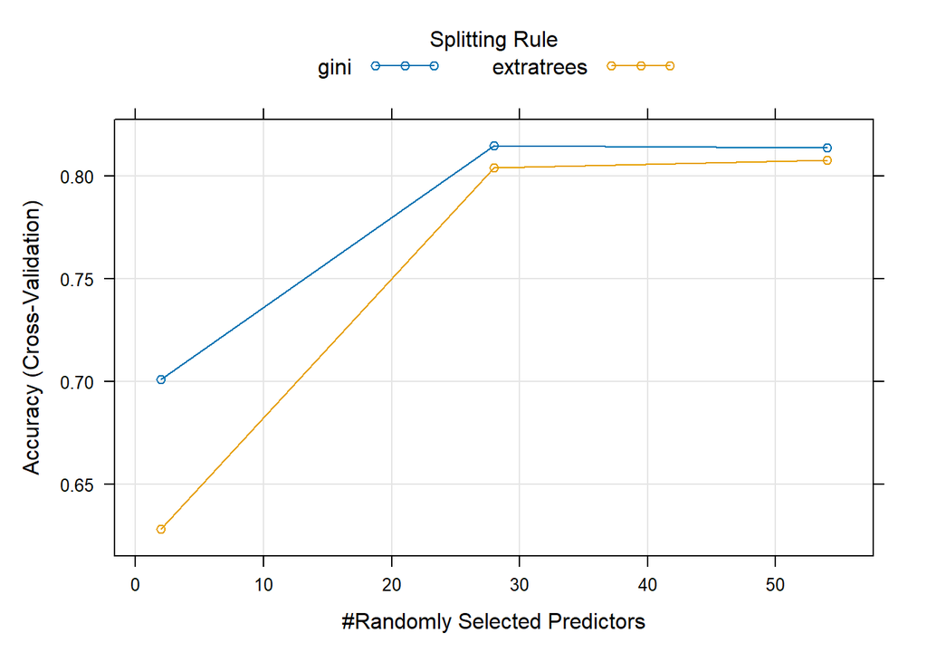

```r
plot(ranger)
```

### 3.6.4

- plot the comparison of the models in 3

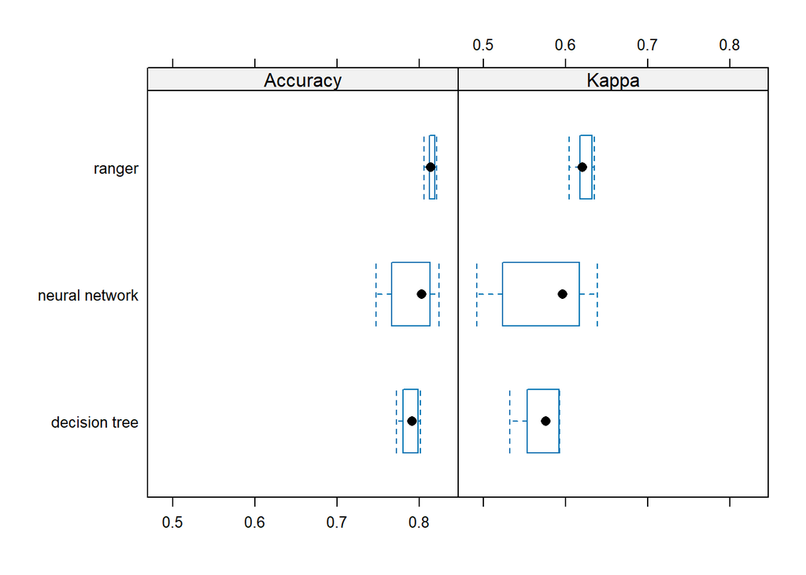

```r
results <- resamples(list ('decision tree' = dt4,
                           'neural network' = nnet,
                           'ranger' = ranger))
bwplot(results)
```

### 3.6.5

```r
pred2 <- predict(ranger, df_test2)

cm2 <- confusionMatrix(data = pred2, reference = df_test2$target2, positive = "high")

cm2$overall[1]
```

```
## Accuracy
## 0.814394
```

## 3.7

- write a paragraph to summarize the section and give your comments on the results

length of stay and total charge are very correlated variables and are the most important predictors of each other. the location/provider and admission type also are important predictors of length of stay. as for total charge, admission type and provider are important predictors as well. ranger proved to be the most successful method of predicting both of my chosen target variables.